# Data structures

Robin Lovelace University of Leeds, 2020-02-05

## Review of homework exercise: demo then individual Q&A

**Note**: Ensure that you have the necessary packages installed. If you do not, you can install them as follows:

```r
install.packages("pct") # install the pct package
```

## Practical demo of zones and lines (in groups)

- Get data on the zones in West Yorkshire with the following command:

```r
zones = pct::get_pct_zones(region = "west-yorkshire")
```

- Find out the class, names, number of columns and number of rows in the `zones` dataset using functions such as `names()`, `nrow()` and `ncol()`.
- Plot the number of car trips and walking trips as follows, what do you notice about the results? Where do you think there is most potential to increase walking levels?

```r
plot(zones["car_driver"])
plot(zones["foot"])
```

- How would you select only the `car_driver` column in the zones object in the tidyverse? Hint it would begin with the following (incomplete) lines:

```r
library(tidyverse)
zones %>% select(
```

- Create a new object called `zones_active_modes` that only contains the `bicycle` and `foot` attribute columns. Plot it (the results should look like those below).

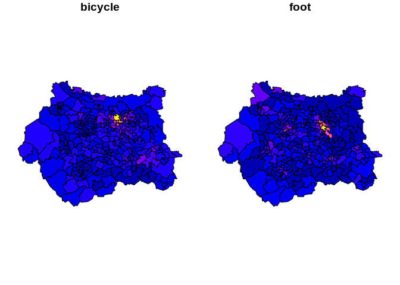

- Which zone has the highest level of cycling, and where is it?
- Use the function `filter()`
- Read-in top 1000 desire lines for Leeds with the following code (hint: rather than typing the url of the file you can copy-paste it from github.com/ITSLeeds/TDS):

```r
library(dplyr)
library(sf)
u = "https://github.com/ITSLeeds/TDS/releases/download/0.1/desire_lines.geojson"

download.file(u, "desire_lines.geojson")
desire_lines = read_sf("desire_lines.geojson")
# note: you can also read-in the file from the url:
# desire_lines = read_sf(u)
```

Plot the lines statically as follows:

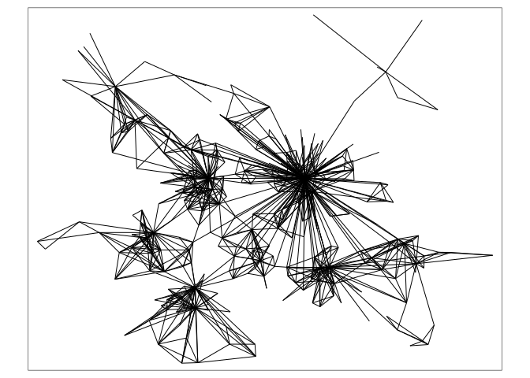

```r
library(tmap)
tm_shape(desire_lines) +
  tm_lines()
```

Plot the lines showing the number of car drivers as follows:

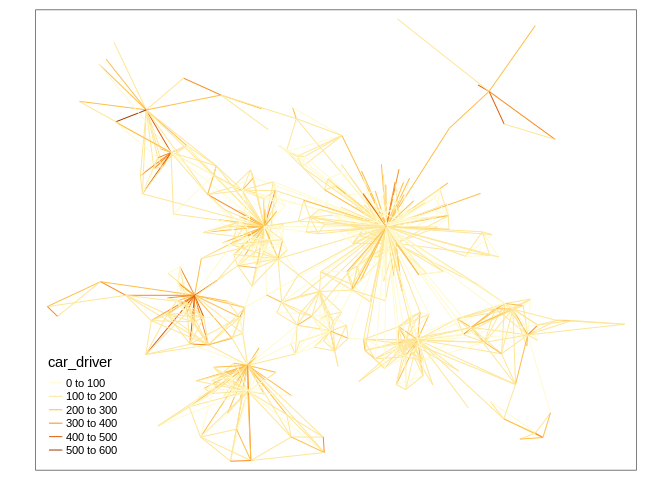

```r
tm_shape(desire_lines) +
  tm_lines(col = "car_driver")
```

- Plot the same lines, but with colour according to the number of people who walked to work in the 2011 Census
- Re-do the plot of the number of trips made by driving, but make the line widths proportional to the total number (`all`) trips made (hint: you may need to set the scale with `scale = 5`, or another number greater than 1, for example)

Filter-out all lines between 1 and 3km and call the resulting object`desire_lines_1_5km` with the following command (or similar):

```r
desire_lines_1_5km = desire_lines %>%
  filter(e_dist_km > 1 & e_dist_km < 3)
```

- Plot the results to make sure the operation worked (you should get a result like the on below):

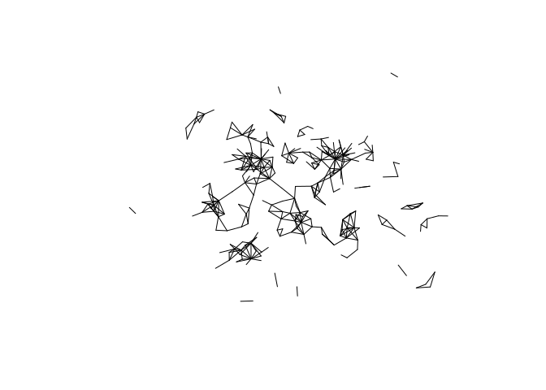

```r
desire_lines_pcar = desire_lines %>%
  mutate(percent_drive = car_driver / all * 100)
```

- Find the top 100 most ‘car dependent’ short desire lines in West Yorkshire and plot the results. It should look something like this:

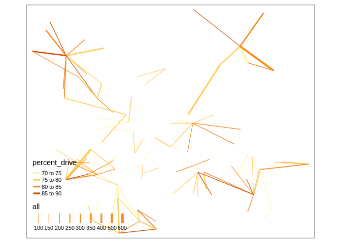

- Plot the results in an interactive map and explore the results. Where are the top 100 most car-dependent major commuting desire lines in West Yorkshire (hint: you may use the `ttm()` function to switch to interactive mode in **tmap**)?

```
## tmap mode set to interactive viewing

## Legend for line widths not available in view mode.
```

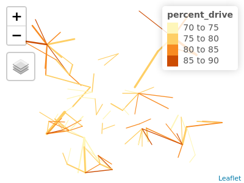

## Homework

- Work through Chapter 12 of Geocomputation with R on Transport - https://geocompr.robinlovelace.net/transport.html
- Save your workings in an R script

Bonus 1 Complete exercise 1 (not bonus)

Bonus 1 (non technical): answer question 3

Bonus 2 (technical): can you reproduce the results for Leeds? This starting point may be useful:

```r
region = "west-yorkshire"
b = "https://github.com/npct/pct-outputs-regional-notR/raw"
u = paste0("/master/commute/msoa/", region)
u_od = paste0(b, u, "/od_attributes.csv")
od = readr::read_csv(u_od)
z = sf::read_sf(paste0(b, u, "/z.geojson"))
cents = sf::read_sf(paste0(b, u, "/c.geojson"))
od_clean = od %>%
  select(-id) %>%
  filter(geo_code1 %in% cents$geo_code) %>%
  filter(geo_code2 %in% cents$geo_code)


desire_lines = stplanr::od2line(flow = od_clean, cents)
tm_shape(desire_lines$geometry[1:99]) %>%
  tm_lines()
```